# Майнор "Интеллектуальный анализ данных"

### Задание 2

Проверьте, присутствуют ли в данных пропущенные значения. Сколько? В каких признаках?  
По каждому такому признаку предложите и обоснуйте, что делать с пропущенными значениями.

```python
columns_nan = list()
if data.isnull().values.any():
    sum_all_nan = data.isnull().sum().sum()  # how many (total)
    print("Total amount of NaN: ", sum_all_nan, '\n')
    print('"Characteristic" : "Amount of Nan"')
    for column in data.columns:
        if data[column].isnull().values.any():
            columns_nan.append(column)
            column_sum = data[column].isnull().sum().sum()
            print(f'{column} : {column_sum}') # where + amount
```

```
Total amount of NaN:  740

"Characteristic" : "Amount of Nan"
romantic : 10
famrel : 10
Dalc : 10
Walc : 10
cheating : 700
```

```python
columns_nan.remove("cheating")
data.drop(columns=["cheating"], axis=1, inplace=True)
print("NaN columns: ", columns_nan)
```

```
NaN columns:  ['romantic', 'famrel', 'Dalc', 'Walc']
```

**Вывод:**

- В колонке **"cheating"** слишком много пропущенных значений (700 из 1044), таким образом его нельзя заменить средним и не потерять в точности. Данную колонку можно убрать из таблицы.
- Колонки **"romantic", "famrel", "Dalc", "Walc"** содержат незначительное кол-во пропусков, которые можно заменить средним значением.

```python
for сolumn in columns_nan:
    print(data.groupby('sex')[сolumn].median())
```

```
sex
F    0.0
M    0.0
Name: romantic, dtype: float64
sex
F    4.0
M    4.0
Name: famrel, dtype: float64
sex
F    1.0
M    1.0
Name: Dalc, dtype: float64
sex
F    2.0
M    3.0
Name: Walc, dtype: float64
```

**!** Делаю проверку, отличается ли медианные значения для мужчин и женщин в столбцах, где есть пропуски.

- Отличия есть только в столбце **"Walc"**.
- Заменяю медианой пропуски в колонках **"romantic", "famrel", "Dalc", "Walc"**.

```python
data["Walc"].fillna(data.groupby("sex")["Walc"].transform('median'),  inplace=True)
columns_nan.remove("Walc")
```

```python
for сolumn in columns_nan:
    avarage = data.loc[:, сolumn].median(skipna = True)
    data.loc[:, сolumn].fillna(avarage, inplace=True)
    print(f"{сolumn}: average value --> {avarage}")
```

```
romantic: average value --> 0.0
famrel: average value --> 4.0
Dalc: average value --> 1.0
```

**!** меняю тип некоторых значений для большего удобства, после устранения пустых значений в колонках.

```python
data['romantic'] = data.romantic.astype('int64')
data['Dalc'] = data.Dalc.astype('int64')
data['Walc'] = data.Walc.astype('int64')
data['famrel'] = data.famrel.astype('int64')
data.dtypes
```

```
ID             int64
Subject       object
school        object
sex           object
age            int64
address       object
famsize       object
Pstatus       object
Medu          object
Fedu          object
Mjob          object
Fjob          object
reason        object
guardian      object
traveltime     int64
studytime      int64
failures       int64
schoolsup      int64
famsup         int64
paid           int64
activities     int64
nursery        int64
higher         int64
internet       int64
romantic       int64
famrel         int64
freetime       int64
goout          int64
Dalc           int64
Walc           int64
health         int64
absences       int64
G1             int64
G2             int64
G3             int64
dtype: object
```

### Задание 3

Проанализируйте данные на наличие выбросов.  
Сколько наблюдений можно отнести к выбросам по каждому признаку? Сколько всего выбросов в данных?

**Note:** Выбросы можно не удалять из данных. Это информацию можно учитывать в дальнейшем анализе и удалять выбросы при необходимости.

```python
data['age'].describe()
```

```
count    1044.000000
mean       16.726054
std         1.239975
min        15.000000
25%        16.000000
50%        17.000000
75%        18.000000
max        22.000000
Name: age, dtype: float64
```

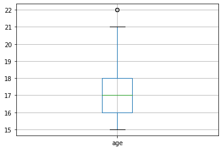

```python
data.boxplot(column=['age'])
```

**Вывод:**

- Для признака age видно, что MAX значение равно 22, в то время как 75% квартиль равен 18.  
  Значение 22 – выброс.

```python
data['failures'].describe()
```

```
count    1044.000000
mean        0.264368
std         0.656142
min         0.000000
25%         0.000000
50%         0.000000
75%         0.000000
max         3.000000
Name: failures, dtype: float64
```

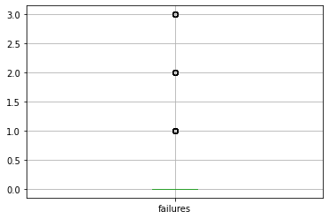

```python
data.boxplot(column=['failures'])
```

**Вывод:**

- Для признака failures видно, что MAX значение равно 3, в то время как 75% квартиль равен 0.  
  Значение 3 – выброс.

```python
data['absences'].describe()
```

```
count    1044.000000
mean        4.434866
std         6.210017
min         0.000000
25%         0.000000
50%         2.000000
75%         6.000000
max        75.000000
Name: absences, dtype: float64
```

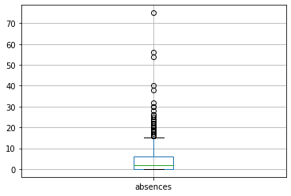

```python
data.boxplot(column=['absences'])
```

**Вывод:**

- Для признака absences видно, что MAX значение равно 75, в то время как 75% квартиль равен только 6.  
  Значение 75 – выброс.

```python
print(f"Discr G1: {data['G1'].describe()}\n")
print(f"Discr G2: {data['G2'].describe()}\n")
print(f"Discr G3: {data['G3'].describe()}\n")
```

```
Discr G1: count    1044.000000
mean       11.213602
std         2.983394
min         0.000000
25%         9.000000
50%        11.000000
75%        13.000000
max        19.000000
Name: G1, dtype: float64

Discr G2: count    1044.000000
mean       11.246169
std         3.285071
min         0.000000
25%         9.000000
50%        11.000000
75%        13.000000
max        19.000000
Name: G2, dtype: float64

Discr G3: count    1044.000000
mean       11.341954
std         3.864796
min         0.000000
25%        10.000000
50%        11.000000
75%        14.000000
max        20.000000
Name: G3, dtype: float64
```

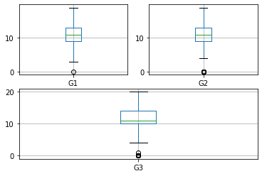

```python
pl.subplot(2,2,1)
data.boxplot(column=['G1'])
pl.subplot(2,2,2)
data.boxplot(column=['G2'])
pl.subplot(2,1,2)
data.boxplot(column=['G3'])
```

### Второй способ (IQR)

Mетод IQR используется для отображения данных и выбросов , но для того, чтобы получить список идентифицированных выбросов. Это мера дисперсии, аналогичная стандартному отклонению или дисперсии, но гораздо более надежная в отношении выбросов. https://en.wikipedia.org/wiki/Interquartile_range

- Сначала рассчитываю IQR:  
  Тут я получаю IQR для каждого столбца.

```python
Q1 = data.quantile(0.25)
Q3 = data.quantile(0.75)
IQR = Q3 - Q1
print(IQR)
```

```
ID            450468.5
age                2.0
traveltime         1.0
studytime          1.0
failures           0.0
schoolsup          0.0
famsup             1.0
paid               0.0
activities         1.0
nursery            0.0
higher             0.0
internet           0.0
romantic           1.0
famrel             1.0
freetime           1.0
goout              2.0
Dalc               1.0
Walc               2.0
health             2.0
absences           6.0
G1                 4.0
G2                 4.0
G3                 4.0
dtype: float64
```

- Теперь фиксирую выбросы. Там, где будет *False*, означает, что эти значения валидны, тогда как *True* указывает на наличие выброса.

```python
out = (data <(Q1 - 1.5 * IQR)) | (data > (Q3 + 1.5 * IQR))
out
```

|  | Dalc | Fedu | Fjob | G1 | G2 | G3 | ID | Medu | Mjob | Pstatus | Subject | Walc | absences | activities | address | age | failures | famrel | famsize | famsup | freetime | goout | guardian | health | higher | internet | nursery | paid | reason | … |
| --- | --- | --- | --- | --- | --- | --- | --- | --- | --- | --- | --- | --- | --- | --- | --- | --- | --- | --- | --- | --- | --- | --- | --- | --- | --- | --- | --- | --- | --- | --- |
| 0 | False | False | False | False | False | False | False | False | False | False | False | False | False | False | False | False | False | False | False | False | False | False | False | False | False | False | False | False | False | … |
| 1 | False | False | False | False | False | False | False | False | False | False | False | False | False | False | False | False | False | False | False | False | False | False | False | False | False | False | True | False | False | … |
| 2 | False | False | False | False | False | False | False | False | False | False | False | False | False | False | False | False | True | False | False | False | False | False | False | False | False | False | True | False | False | … |
| 3 | False | False | False | False | False | False | False | False | False | False | False | False | False | False | False | False | False | False | False | False | False | False | False | False | False | False | False | False | False | … |
| 4 | False | False | False | False | False | False | False | False | False | False | False | False | False | False | False | False | False | False | False | False | False | False | False | False | False | True | False | False | False | … |
| ... | ... | ... | ... | ... | ... | ... | ... | ... | ... | ... | ... | ... | ... | ... | ... | ... | ... | ... | ... | ... | ... | ... | ... | ... | ... | ... | ... | ... | ... | … |
| 1039 | False | False | False | False | False | False | False | False | False | False | False | False | False | False | False | False | True | False | False | False | False | False | False | False | False | False | False | True | False | … |
| 1040 | False | False | False | False | False | False | False | False | False | False | False | False | False | False | False | False | False | False | False | False | False | False | False | False | False | False | False | False | False | … |
| 1041 | False | False | False | False | False | False | False | False | False | False | False | False | False | False | False | False | False | False | False | False | False | False | False | False | False | True | False | False | False | … |
| 1042 | False | False | False | False | False | False | False | False | False | False | False | False | False | False | False | False | False | False | False | False | False | False | False | False | False | True | False | False | False | … |
| 1043 | False | False | False | False | False | False | False | False | False | False | False | False | False | False | False | False | True | False | False | False | False | False | False | False | False | False | False | False | False | … |

1044 rows × 35 columns

```python
for col in data.columns:
    outer = (data[col] == True).sum()
    if outer != 0:
        print(f'{col} -> ВЫБРОСОВ: -> {outer}')
```

```
traveltime -> ВЫБРОСОВ: -> 623
studytime -> ВЫБРОСОВ: -> 317
failures -> ВЫБРОСОВ: -> 120
schoolsup -> ВЫБРОСОВ: -> 119
famsup -> ВЫБРОСОВ: -> 640
paid -> ВЫБРОСОВ: -> 220
activities -> ВЫБРОСОВ: -> 516
nursery -> ВЫБРОСОВ: -> 835
higher -> ВЫБРОСОВ: -> 955
internet -> ВЫБРОСОВ: -> 827
romantic -> ВЫБРОСОВ: -> 370
famrel -> ВЫБРОСОВ: -> 30
freetime -> ВЫБРОСОВ: -> 64
goout -> ВЫБРОСОВ: -> 71
Dalc -> ВЫБРОСОВ: -> 729
Walc -> ВЫБРОСОВ: -> 393
health -> ВЫБРОСОВ: -> 137
absences -> ВЫБРОСОВ: -> 15
G3 -> ВЫБРОСОВ: -> 1
```

### Задание 11 (перенесла задаие, так как в некоторых номерах делаю анализ отталкиваясь от данных, созданных в этом задании)

Часть из представленных в данных студентов посещали оба курса - `Math` и `Por`.

- Предложите способ идентификации студентов и определите тех, кто посещал оба курса. Сколько таких студентов?
- Для этих студентов сравните оценки по двум предметам, дайте комментарий.

**Note:** Столбец `ID` является уникальным идентификатором наблюдения, но не студента. Он будет уникален для каждой строки.

```python
# Предложите способ идентификации студентов и определите тех, кто посещал оба курса.

new_data = data.copy()  # create new dataframe
new_data.drop(columns=['Subject', 'studytime', 'failures', 'absences','paid', 'G1', 'G2', 'G3'], axis=1, inplace=True)
duplicate = new_data[new_data.duplicated(subset=['school','sex','age','address','famsize','Pstatus','Medu','Fedu','Mjob',
                            'Fjob','reason','guardian','traveltime','schoolsup',
                            'famsup','activities', 'nursery','higher','internet','romantic','famrel',
                            'freetime','goout','Dalc','Walc','health'])]
```

```python
from itertools import repeat

size = len(data.loc[:, 'ID'])
both_course = [0 for i in repeat(None, size)]

for index, row in duplicate.iterrows():
    id = duplicate['ID'][index]
    exist = data.loc[data['ID'] == id]
    if len(exist) > 0:
        both_course[index] = 1
data['both_course'] = both_course
```

1) Я считаю, что одним из хороших способов идентификации студентов будет удаление из копии оригинального DataFrame столбцов:

- **Subject:** так как человек посещал и математику и португальский;
- **studytime:** так как студенты, которые ходят на оба курса, явно тратят больше времени на учебу;
- **failures:** вероятно такие стеденты могут иметь больше завалов по курсам.
- **absences:** их отсутствие также будет высчитываться исходя из посещения обоих курсов;
- **paid:** оплата сильно отличается, если студент платит за два курса;
- **G1, G2, G3:** так как оценки по разным предметам будут соответственно отличаться;

2) Далее использую функцию **duplicated()** находятся одинаковые строки - это и есть студенты, посещающие оба курса.  
3) Так как я сохранила **ID** студента, то могу теперь создать еще одну колонку в оригинальном DataFrame и отметить там тех, кто посещал оба курса (0 - не посещал, 1 - посещал)

```python
# Сколько таких студентов?
index = duplicate.index
number_of_rows = len(index)
print(f'Число студентов, которые посещают курсы по математике и португальскому: {number_of_rows}')
```

```
Число студентов, которые посещают курсы по математике и португальскому: 359
```

```python
# Для этих студентов сравните оценки по двум предметам, дайте комментарий.
sts_of_both = data[data['both_course']==1]
port = sts_of_both[sts_of_both['Subject']=='Por']
math = sts_of_both[sts_of_both['Subject']=='Math']
```

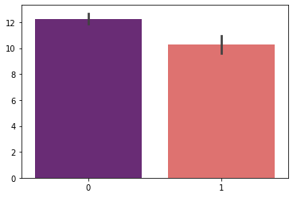

```python
sb.barplot(data=[port['G3'], math['G3']], palette="magma" )
```

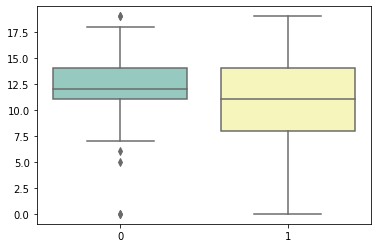

```python
sb.boxplot(data=[port['G3'], math['G3']],
           palette="Set3")
```

### Задание 4

- Посчитайте описательные статистики для числовых и для категориальных признаков.
- Сколько студентов посещают каждую из школ?
- Сколько студентов посещают математику, сколько - португальский?
- Студенты какого курса чаще заваливают экзамены?
- Сколько в среднем времени в неделю уходит на учебу по каждому предмету?
- На что чаще обращают внимание при выборе школы?

```python
# 1.  Посчитайте описательные статистики для числовых и для категориальных признаков.
data.describe(include='all')
```

|  | ID | Subject | school | sex | age | address | famsize | Pstatus | Medu | Fedu | Mjob | Fjob | reason | guardian | traveltime | studytime | failures | schoolsup | famsup | paid | activities | nursery | higher | internet | romantic | famrel | freetime | goout | Dalc | … |
| --- | --- | --- | --- | --- | --- | --- | --- | --- | --- | --- | --- | --- | --- | --- | --- | --- | --- | --- | --- | --- | --- | --- | --- | --- | --- | --- | --- | --- | --- | --- |
| count | 1044.000000 | 1044 | 1044 | 1044 | 1044.000000 | 1044 | 1044 | 1044 | 1044 | 1044 | 1044 | 1044 | 1044 | 1044 | 1044.000000 | 1044.000000 | 1044.000000 | 1044.000000 | 1044.000000 | 1044.000000 | 1044.000000 | 1044.000000 | 1044.000000 | 1044.000000 | 1044.000000 | 1044.000000 | 1044.000000 | 1044.000000 | 1044.000000 | … |
| unique | NaN | 2 | 2 | 2 | NaN | 2 | 2 | 2 | 5 | 5 | 5 | 5 | 4 | 3 | NaN | NaN | NaN | NaN | NaN | NaN | NaN | NaN | NaN | NaN | NaN | NaN | NaN | NaN | NaN | … |
| top | NaN | Por | GP | F | NaN | U | GT3 | T | 4 | 2 | other | other | course | mother | NaN | NaN | NaN | NaN | NaN | NaN | NaN | NaN | NaN | NaN | NaN | NaN | NaN | NaN | NaN | … |
| freq | NaN | 649 | 772 | 591 | NaN | 759 | 738 | 923 | 306 | 324 | 399 | 584 | 430 | 728 | NaN | NaN | NaN | NaN | NaN | NaN | NaN | NaN | NaN | NaN | NaN | NaN | NaN | NaN | NaN | … |
| mean | 547057.190613 | NaN | NaN | NaN | 16.726054 | NaN | NaN | NaN | NaN | NaN | NaN | NaN | NaN | NaN | 1.522989 | 1.970307 | 0.264368 | 0.113985 | 0.613027 | 0.210728 | 0.494253 | 0.799808 | 0.914751 | 0.792146 | 0.354406 | 3.936782 | 3.201149 | 3.156130 | 1.492337 | … |
| std | 263827.330362 | NaN | NaN | NaN | 1.239975 | NaN | NaN | NaN | NaN | NaN | NaN | NaN | NaN | NaN | 0.731727 | 0.834353 | 0.656142 | 0.317945 | 0.487291 | 0.408021 | 0.500207 | 0.400335 | 0.279386 | 0.405967 | 0.478562 | 0.928833 | 1.031507 | 1.152575 | 0.911700 | … |
| min | 100097.000000 | NaN | NaN | NaN | 15.000000 | NaN | NaN | NaN | NaN | NaN | NaN | NaN | NaN | NaN | 1.000000 | 1.000000 | 0.000000 | 0.000000 | 0.000000 | 0.000000 | 0.000000 | 0.000000 | 0.000000 | 0.000000 | 0.000000 | 1.000000 | 1.000000 | 1.000000 | 1.000000 | … |
| 25% | 324017.500000 | NaN | NaN | NaN | 16.000000 | NaN | NaN | NaN | NaN | NaN | NaN | NaN | NaN | NaN | 1.000000 | 1.000000 | 0.000000 | 0.000000 | 0.000000 | 0.000000 | 0.000000 | 1.000000 | 1.000000 | 1.000000 | 0.000000 | 4.000000 | 3.000000 | 2.000000 | 1.000000 | … |
| 50% | 554339.500000 | NaN | NaN | NaN | 17.000000 | NaN | NaN | NaN | NaN | NaN | NaN | NaN | NaN | NaN | 1.000000 | 2.000000 | 0.000000 | 0.000000 | 1.000000 | 0.000000 | 0.000000 | 1.000000 | 1.000000 | 1.000000 | 0.000000 | 4.000000 | 3.000000 | 3.000000 | 1.000000 | … |
| 75% | 774486.000000 | NaN | NaN | NaN | 18.000000 | NaN | NaN | NaN | NaN | NaN | NaN | NaN | NaN | NaN | 2.000000 | 2.000000 | 0.000000 | 0.000000 | 1.000000 | 0.000000 | 1.000000 | 1.000000 | 1.000000 | 1.000000 | 1.000000 | 5.000000 | 4.000000 | 4.000000 | 2.000000 | … |
| max | 999194.000000 | NaN | NaN | NaN | 22.000000 | NaN | NaN | NaN | NaN | NaN | NaN | NaN | NaN | NaN | 4.000000 | 4.000000 | 3.000000 | 1.000000 | 1.000000 | 1.000000 | 1.000000 | 1.000000 | 1.000000 | 1.000000 | 1.000000 | 5.000000 | 5.000000 | 5.000000 | 5.000000 | … |

```python
# 2.  Сколько студентов посещают каждую из школ?
gp_amount = len(data[data['school'] == 'GP'])
print('Gabriel Pereira: ', gp_amount)
ms_amount = len(data[data['school'] == 'MS'])
print('Mousinho da Silveira: ', ms_amount)
```

```
Gabriel Pereira:  772
Mousinho da Silveira:  272
```

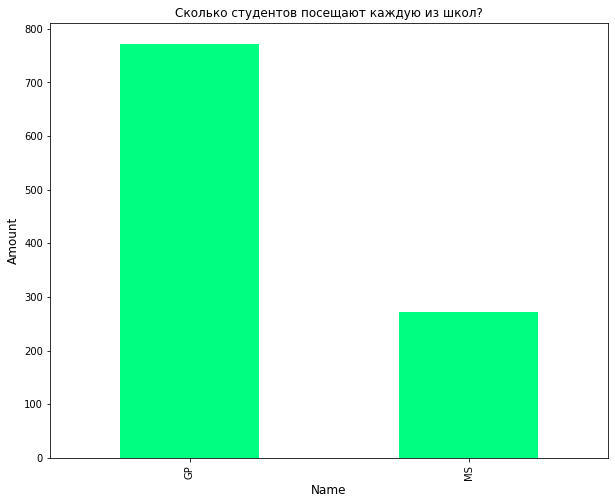

```python
diff_values = data['school'].value_counts()
ax = diff_values.plot(kind='bar', title ='Сколько студентов посещают каждую из школ?',
                      figsize=(10, 8), fontsize=10,  color='#00ff80')
ax.set_xlabel('Name', fontsize=12)
ax.set_ylabel('Amount', fontsize=12)
```

```python
# 3.  Сколько студентов посещают математику, сколько - португальский?
math_amount =  len(data[data['Subject'] == 'Math'])
port_amount = len(data[data['Subject'] == 'Por'])
print('Math: ', math_amount)
print('Portuguese: ', port_amount)
```

```
Math:  395
Portuguese:  649
```

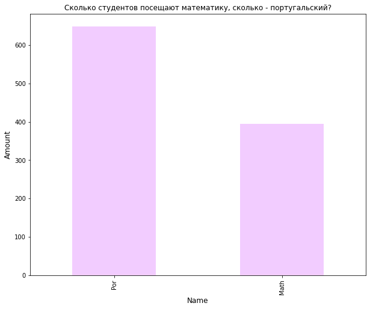

```python
diff_values = data['Subject'].value_counts()
ax = diff_values.plot(kind='bar', title ='Сколько студентов посещают математику, сколько - португальский?', figsize=(10, 8), fontsize=10,  color='#f2ccff')
ax.set_xlabel('Name', fontsize=12)
ax.set_ylabel('Amount', fontsize=12)
```

**!** Оценка в 9 баллов и ниже была выбрана из-за статьи: https://en.wikipedia.org/wiki/Academic_grading_in_Portugal#:~:text=4%20(good)%20(70%2D,grade%20(0%2D19%25).

```python
# 4.  Студенты какого курса чаще заваливают экзамены?
port_per = len(data.loc[(data['G3'] <= 9) & (data['Subject'] == 'Por')]) / port_amount
math_per = len(data.loc[(data['G3'] <= 9) & (data['Subject'] == 'Math')]) / math_amount
if port_per > math_per:
    print(f"Students of the PORTUGUESE language course fail the exam more often: {port_per} compared with MATH course {math_per}.")
else:
    print(f"Students of the MATH course fail the exam more often: {math_per} compared with PORT. lang. course {port_per}.")
```

```
Students of the MATH course fail the exam more often: 0.3291139240506329 compared with PORT. lang. course 0.15408320493066255.
```

**!** В **11 задании** были отмечены студенты, которые посещают оба курса, исключив их, мы видим, что по математике все равно курсы заваливают чаще.

```python
port_per = len(data.loc[(data['G3'] <= 9) & (data['Subject'] == 'Por') & (data['both_course'] == 0)]) / port_amount
math_per = len(data.loc[(data['G3'] <= 9) & (data['Subject'] == 'Math') & (data['both_course'] == 0)]) / math_amount
if port_per > math_per:
    print(f"Students of the PORTUGUESE language course fail the exam more often: {port_per} compared with MATH course {math_per}.")
else:
    print(f"Students of the MATH course fail the exam more often: {math_per} compared with PORT. lang. course {port_per}.")
```

```
Students of the MATH course fail the exam more often: 0.17721518987341772 compared with PORT. lang. course 0.1263482280431433.
```

```python
# 5.  Сколько в среднем времени в неделю уходит на учебу по каждому предмету?
port_time_aver = data.loc[data['Subject'] == 'Por', 'studytime'].median()
if port_time_aver == 1.0:
     print("Students spend on PORTUGUESE < 2 hours per week.")
elif port_time_aver == 2.0:
    print("Students spend on PORTUGUESE from 2 to 5 hours per week.")
elif port_time_aver == 3.0:
     print("Students spend on PORTUGUESE from 5 to 10 hours per week.")
elif port_time_aver == 4.0:
    print("Students spend on PORTUGUESE > 10 hours per week.")

math_time_aver = data.loc[data['Subject'] == 'Math', 'studytime'].median()
if math_time_aver == 1.0:
     print("Students spend on MATH < 2 hours per week.")
elif math_time_aver == 2.0:
    print("Students spend on MATH from 2 to 5 hours per week.")
elif math_time_aver == 3.0:
     print("Students spend on MATH from 5 to 10 hours per week.")
elif math_time_aver == 4.0:
    print("Students spend on MATH > 10 hours per week.")
```

```
Students spend on PORTUGUESE from 2 to 5 hours per week.
Students spend on MATH from 2 to 5 hours per week.
```

**!** В **11 задании** были отмечены студенты, которые посещают оба курса, исключив их, мы видим, что такое же время тратят студенты на учебу.

```python
port_time_aver = data.loc[(data['Subject'] == 'Por') & (data['both_course'] == 0), 'studytime'].median()
if port_time_aver == 1.0:
     print("Students spend on PORTUGUESE < 2 hours per week.")
elif port_time_aver == 2.0:
    print("Students spend on PORTUGUESE from 2 to 5 hours per week.")
elif port_time_aver == 3.0:
     print("Students spend on PORTUGUESE from 5 to 10 hours per week.")
elif port_time_aver == 4.0:
    print("Students spend on PORTUGUESE > 10 hours per week.")

math_time_aver = data.loc[(data['Subject'] == 'Math') & (data['both_course'] == 0), 'studytime'].median()
if math_time_aver == 1.0:
     print("Students spend on MATH < 2 hours per week.")
elif math_time_aver == 2.0:
    print("Students spend on MATH from 2 to 5 hours per week.")
elif math_time_aver == 3.0:
     print("Students spend on MATH from 5 to 10 hours per week.")
elif math_time_aver == 4.0:
    print("Students spend on MATH > 10 hours per week.")
```

```
Students spend on PORTUGUESE from 2 to 5 hours per week.
Students spend on MATH from 2 to 5 hours per week.
```

```python
# 6  На что чаще обращают внимание при выборе школы?
print(f"The main reason of choosing school is: {str(data.reason.mode()).split()[1]}.")
```

```
The main reason of choosing school is: course.
```

### Задание 5

Оцените распределение оценок (отдельно для `G1`, `G2` и `G3`). Сравните распределения для разных предметов - математики и португальского языка. Сделайте выводы.

**Tip:** Для выполнения задания пригодятся графики плотности, гистограммы и боксплоты.

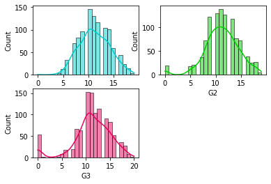

```python
pl.subplot (2, 2, 1)
sb.histplot(data=data['G1'], kde=True, color="#00cccc")
pl.subplot (2, 2, 2)
sb.histplot(data=data['G2'], kde=True, color="#00cc00")
pl.subplot (2, 2, 3)
sb.histplot(data=data['G3'], kde=True, color="#e6005c")
```

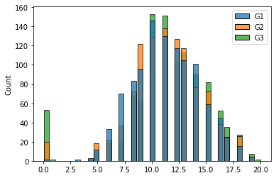

```python
sb.histplot(data=[data['G1'], data['G2'], data['G3']],  multiple="dodge", shrink=.8)
```

**Вывод:**  
1) Средняя плотность распределения оценок сохранилась во всех трех рассматренных вариантах (два полугодия + итог).  
2) Рост отличных оценок наблюдался только во 2ом полугодии.  
3) По сравнению с 1ым полугодием, во 2ом - кол-во нулевых оценок значительно выросло, а в итоговой оценке этот параметр подрос почти в 3 раза.

**Математика**(плотность оценок)

```python
math = data.loc[data['Subject']=='Math', ['G1', 'G2', 'G3']]
```

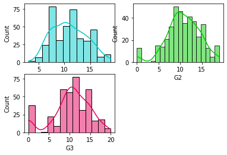

```python
pl.subplot (2, 2, 1)
sb.histplot(data=math['G1'], kde=True, color="#00cccc")
pl.subplot (2, 2, 2)
sb.histplot(data=math['G2'], kde=True, color="#00cc00")
pl.subplot (2, 2, 3)
sb.histplot(data=math['G3'], kde=True, color="#e6005c")
```

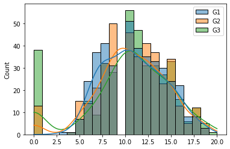

```python
sb.histplot(data=[math['G1'], math['G2'], math['G3']], kde=True)
```

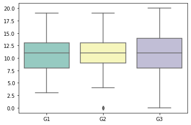

```python
ax = sb.boxplot(data=math, palette="Set3")
```

**Вывод (математика):**  
1) Во 2ом полугодии и в итоговых оценках явно заметен рост нулевых оценок. Особенно их много в итоговых оценках.  
2) По сравнению с 1ым полугодием уменьшились оценки "ниже среднего" в итоговых оценках.  
3) В первом полугодии превалировали средние оценки и ниже среднего.  
4) Во втором полугодии увеличилось кол-во хороших и отличных оценок.  
5) В итоговых оценках можно отметить увеличение низких оценок и уменьшение высоких.

**Португальский язык**(плотность оценок)

```python
por = data.loc[data['Subject']=='Por', ['G1', 'G2', 'G3']]
```

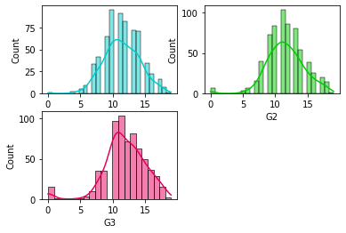

```python
pl.subplot (2, 2, 1)
sb.histplot(data=por['G1'], kde=True, color="#00cccc")
pl.subplot (2, 2, 2)
sb.histplot(data=por['G2'], kde=True, color="#00cc00")
pl.subplot (2, 2, 3)
sb.histplot(data=por['G3'], kde=True, color="#e6005c")
```

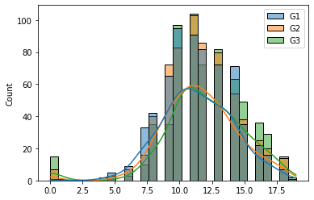

```python
sb.histplot(data=[por['G1'], por['G2'], por['G3']], kde=True)
```

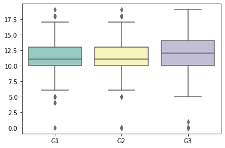

```python
ax = sb.boxplot(data=por, palette="Set3")
```

**Вывод (португальский):**  
1) Нулевые оценки подросли во втором полугодии и примерно на столько же выросли к концу года.  
2) Виден рост "хороших" итоговых оценок.  
3) "Средние" оценки преобладают.

## **Общий вывод:**

### Задание 6

Оцените попарные зависимости числовых признаков.  
Рассчитайте и провизуализируйте матрицу корреляций. Дайте содержательный комментарий.

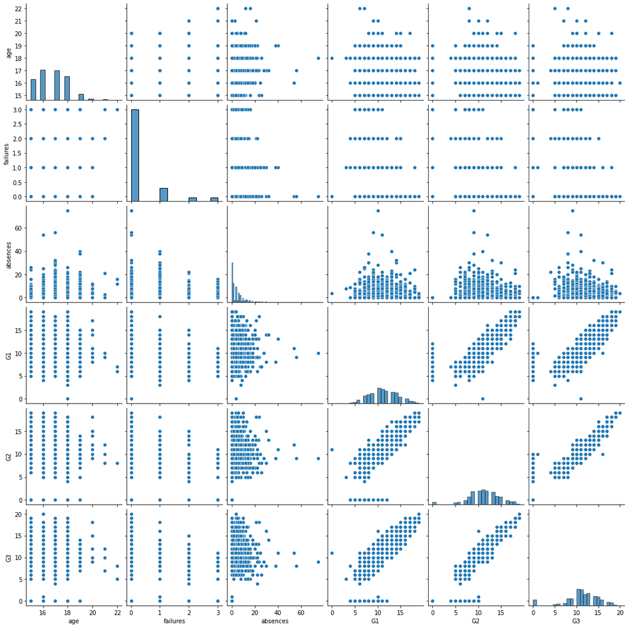

```python
numeric = ["ID", "age", "failures", "absences", "G1", "G2", "G3"]
sb.pairplot(data=data.loc[:,numeric[1:]])
```

```python
num_data = data.loc[:,numeric]
corr_matrix = num_data.corr().round(4)
corr_matrix
```

|  | ID | age | failures | absences | G1 | G2 | G3 |
| --- | --- | --- | --- | --- | --- | --- | --- |
| ID | 1.0000 | 0.0083 | 0.0105 | -0.0409 | 0.0446 | 0.0228 | 0.0155 |
| age | 0.0083 | 1.0000 | 0.2824 | 0.1532 | -0.1241 | -0.1195 | -0.1253 |
| failures | 0.0105 | 0.2824 | 1.0000 | 0.1000 | -0.3742 | -0.3772 | -0.3831 |
| absences | -0.0409 | 0.1532 | 0.1000 | 1.0000 | -0.0924 | -0.0893 | -0.0457 |
| G1 | 0.0446 | -0.1241 | -0.3742 | -0.0924 | 1.0000 | 0.8587 | 0.8091 |
| G2 | 0.0228 | -0.1195 | -0.3772 | -0.0893 | 0.8587 | 1.0000 | 0.9107 |
| G3 | 0.0155 | -0.1253 | -0.3831 | -0.0457 | 0.8091 | 0.9107 | 1.0000 |

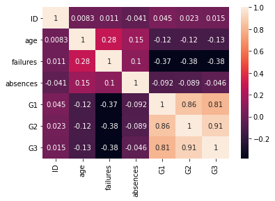

```python
sb.heatmap(corr_matrix, annot=True)
```

### Задание 7

Оцените попарные зависимости нечисловых (категориальных) признаков, дайте содержательный комментарий.

```python
categorial = ["Subject", "school", "sex", "address", "famsize", "Pstatus",
              "Medu", "Fedu", "Mjob", "Fjob", "reason", "guardian",  "traveltime",
              "studytime", "schoolsup", "famsup", "paid", "activities", "nursery",
              "higher", "internet", "romantic","famrel", "freetime", "goout",
              "Dalc", "Walc", "health"]
```

**!** здесь не особо удобно использовать функцию "pairplot", поэтому признаки будут рассматриваться отдельно (те прихзнаки, по которым можно дать интересный и содержательный комментарий).

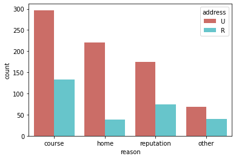

```python
sb.countplot(data=data, x="reason", hue="address", palette="hls")
```

1) Самое большое предпочтение у студентов, живущих в городе и за городом вызвали **курсы** при выборе школы.  
2) Второй по значимости причиной для выбора школы для студентов из города стало ее **расположение относительно дома**. А для студентов, живущих за городом, вторая важная присина - это **репутация школы** .  
3) Для студентов, живущих в городе меньше всего значила причина **другое**, а для сельских жителей причина - **расположение относительно школы** .

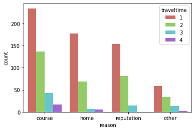

```python
sb.countplot(data=data, x="reason", hue="traveltime", palette="hls")
```

1) Как и следовало ожидать, те, кто выбрал школу из-за ее **близкого расположения от дома**, добираются **быстро**.

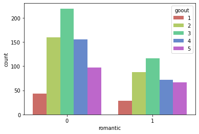

```python
sb.countplot(data=data, x="romantic", hue="goout", palette="hls")
```

1) Можно сказать, что **наличие отношений** практически **не влияет** на встречи с друзьями, лишь немного снижен показатель "4"(частые встречи с друзьями) у тех, кто в отношениях.

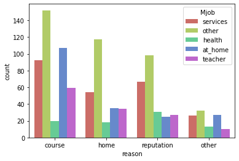

```python
sb.countplot(data=data, x="reason", hue="Mjob", palette="hls")
```

1) Видно, что те **матери**, которые работают в **администрации и полиции**, а также те, у кого **домашняя занятость** - их дети отдавали предпочтение выбору школы по **преподаваемым курсам**.

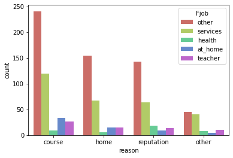

```python
sb.countplot(data=data, x="reason", hue="Fjob", palette="hls")
```

1) Дети **отцов**, также работяющих в **администрации и полиции**, отдавали предпочтение выбору школы по **преподаваемым курсам**.

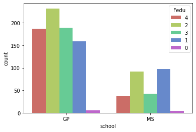

```python
sb.countplot(data=data, x="school", hue="Fedu", palette="hls")
```

1) Отцы, чье образование было **от 5 до 9 классов** - их дети выбирали школу **Gabriel Pereira** .  
2) Отцы, кто закончил только **начальную школу** - их дети выбирали школу **Mousinho da Silveira** .

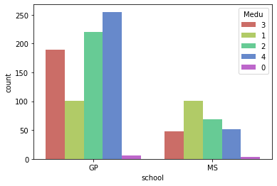

```python
sb.countplot(data=data, x="school", hue="Medu", palette="hls")
```

1) Матери, кто имеет **высшее образование** - их дети выбирали школу **Gabriel Pereira** .  
2) Матери, кто закончил только **начальную школу** - их дети выбирали школу **Mousinho da Silveira** .

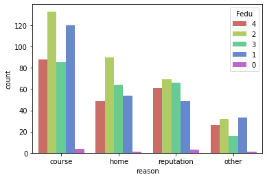

```python
sb.countplot(data=data, x="reason", hue="Fedu", palette="hls")
```

1) Отцы, чье образование **от 5 до 9 классов** - их дети **чаще всего** выбирали школу из-за предоставляемых **курсов**. В остальных причинах также преобладают отцы, закончившие 5-9 классов (кроме "other").

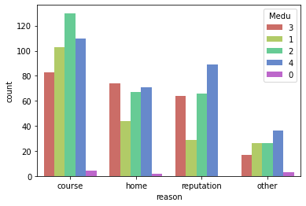

```python
sb.countplot(data=data, x="reason", hue="Medu", palette="hls")
```

1) Матери, чье образование **от 5 до 9 классов** - их дети **чаще всего** выбирали школу из-за предоставляемых **курсов** .  
2) Матери, которые имеют **среднее образование** - их дети выбирали школу по причине: **близость от дома** .  
3) Матери, имеющие **высшее образование** - их дети выбирали школу из-за ее **репутаци**.

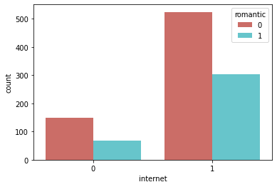

```python
sb.countplot(data=data, x="internet", hue="romantic", palette="hls")
```

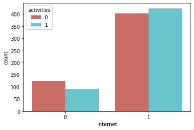

```python
sb.countplot(data=data, x="internet", hue="activities", palette="hls")
```

1) Интересно отметить, что большинство студентов, имеющих **доступ к интернету**, **участвуют** во внеучебной активности, а те, у кого **нет доступа**(коих меньшинство) - **не участвуют** во внеучебной активности.

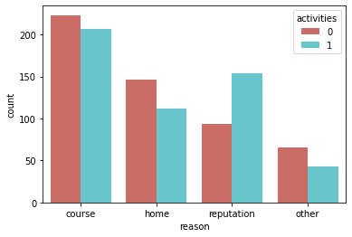

```python
sb.countplot(data=data, x="reason", hue="activities", palette="hls")
```

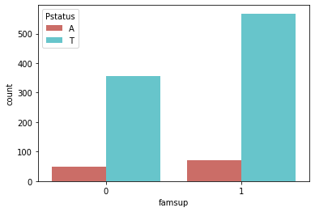

```python
sb.countplot(data=data, x="famsup", hue="Pstatus", palette="hls")
```

1) То, что родители живут вместе или раздельно - **не влияет** на помощь детям по учебе.

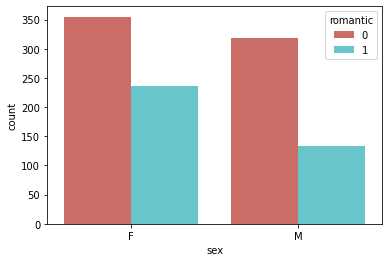

```python
sb.countplot(data=data, x="sex", hue="romantic", palette="hls")
```

1) **Больше девушек** состоят в отношениях, чем парней, однако превалирует большинство **свободных** от отношений студентов.

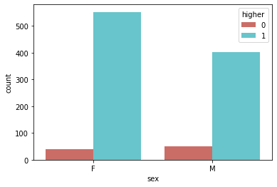

```python
sb.countplot(data=data, x="sex", hue="higher", palette="hls")
```

1) Больше парней решили **не получать** высшее образование.  
2) Больше девушек решили **получать** высшее образование.

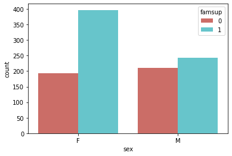

```python
sb.countplot(data=data, x="sex", hue="famsup", palette="hls")
```

1) Семья больше **помогает девушкам** по учебе, чем молодым людям.

### Задание 8

- Оцените, есть ли разница в употреблении алкоголя между парнями и девушками. Кто пьет больше?
- Оцените связь употребления алкоголя с признаками: address, Pstatus, higher, romantic, freetime.
- Оцените связь употребления алкоголя с уровнем образования опекуна (для случаев, где это известно).
- Сравните употребление алкоголя для 50 лучших учеников и 50 худших (по `G3`). Выполните сравнение отдельно для каждого предмета (`Math` и `Por`). Дайте содержательный комментарий.

**Tip:** для выполнения задания пригодятся боксплоты и гистограммы.

```python
# Оцените, есть ли разница в употреблении алкоголя между парнями и девушками. Кто пьет больше?

def alc_avr(d):
    return (d[0] + d[1]) // 2
```

```python
data['alc_av_consump'] = data.loc[:, ['Walc', 'Dalc']].apply(alc_avr, axis=1)
data.head()
```

|  | ID | Subject | school | sex | age | address | famsize | Pstatus | Medu | Fedu | Mjob | Fjob | reason | guardian | traveltime | studytime | failures | schoolsup | famsup | paid | activities | nursery | higher | internet | romantic | famrel | freetime | goout | Dalc | … |
| --- | --- | --- | --- | --- | --- | --- | --- | --- | --- | --- | --- | --- | --- | --- | --- | --- | --- | --- | --- | --- | --- | --- | --- | --- | --- | --- | --- | --- | --- | --- |
| 0 | 100097 | Por | GP | F | 16 | U | GT3 | A | 3 | 4 | services | other | course | father | 1 | 1 | 0 | 0 | 0 | 0 | 0 | 1 | 1 | 1 | 0 | 3 | 2 | 1 | 1 | … |
| 1 | 101021 | Por | GP | F | 17 | U | GT3 | T | 3 | 2 | other | other | course | mother | 1 | 2 | 0 | 0 | 0 | 0 | 1 | 0 | 1 | 1 | 0 | 5 | 3 | 4 | 1 | … |
| 2 | 102965 | Por | GP | M | 16 | U | LE3 | T | 1 | 2 | health | services | course | mother | 2 | 1 | 2 | 0 | 0 | 0 | 0 | 0 | 1 | 1 | 0 | 4 | 4 | 5 | 3 | … |
| 3 | 102989 | Por | MS | M | 17 | U | GT3 | T | 2 | 3 | other | services | home | father | 2 | 2 | 0 | 0 | 0 | 0 | 1 | 1 | 1 | 1 | 0 | 4 | 4 | 3 | 1 | … |
| 4 | 103131 | Por | GP | F | 16 | U | GT3 | T | 1 | 1 | at_home | other | home | mother | 2 | 1 | 0 | 0 | 1 | 0 | 0 | 1 | 1 | 0 | 0 | 4 | 3 | 2 | 1 | … |

```python
print('Шкала употребления алкоголя (1 - очень мало, 5 - очень много): \nУпотребление алкоголя:')
print("Boys: ", data.loc[data['sex']=='M', 'alc_av_consump'].median())
print("Girls: ", data.loc[data['sex']=='F', 'alc_av_consump'].median())
```

```
Шкала употребления алкоголя (1 - очень мало, 5 - очень много):
Употребление алкоголя:
Boys:  2.0
Girls:  1.0
```

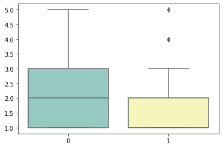

```python
sb.boxplot(data=[data.loc[data['sex']=='M', 'alc_av_consump'], data.loc[data['sex']=='F', 'alc_av_consump']], palette="Set3")
```

**Вывод:**  
Больше пьют парни.

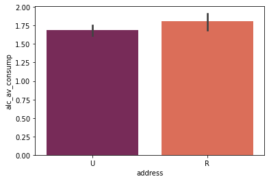

```python
sb.barplot(data=data, x='address', y='alc_av_consump', palette="rocket")
```

**Вывод:**

- (Студент: R - живет за городом, U - в городе) Пьют алкоголь больше те, кто живет за городом.

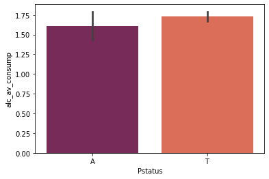

```python
# Cвязь употребления алкоголя с признаком Pstatus
sb.barplot(data=data, x='Pstatus', y='alc_av_consump', palette="rocket")
```

**Вывод:**

- (Родители : 'T' - живут вместе, 'A' - живут раздельно) Пьют больше те студенты, чьи родители живут вместе.

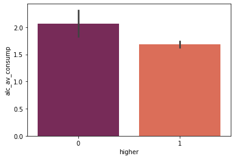

```python
# Cвязь употребления алкоголя с признаком higher
sb.barplot(data=data, x='higher', y='alc_av_consump', palette="rocket")
```

**Вывод:**

- (1 - да, 0 - нет) Пьют больше те студенты,кто не собирается получать высшее образование.

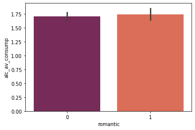

```python
# Cвязь употребления алкоголя с признаком romantic
sb.barplot(data=data, x='romantic', y='alc_av_consump', palette="rocket")
```

**Вывод:**

- (1 - да, 0 - нет) Разница в употреюлени алкоголя между теми, кто состоит в романтических отношениях, а кто нет - крайне мала. Можно сделать вывод, что романтические отношения никак не влияют на кол-во употребляемого алкоголя.

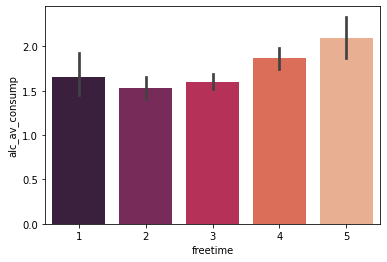

```python
# Cвязь употребления алкоголя с признаком freetime
sb.barplot(data=data, x='freetime', y='alc_av_consump', palette="rocket")
```

**Вывод:** (Свободное время после занятий: от 1 - очень мало, до 5 - очень много)

- Пьют больше те студенты, у которых больше всего свободного времени.
- Студенты, у которых крайне мало и средне свободного времени употребляют алкоголь практически в одинаковых количествах.

```python
# Оцените связь употребления алкоголя с уровнем образования опекуна (для случаев, где это известно).
gm_alc = data.loc[data['guardian']=='mother', ['alc_av_consump', 'Medu']]
gf_alc = data.loc[data['guardian']=='father', ['alc_av_consump', 'Fedu']]
```

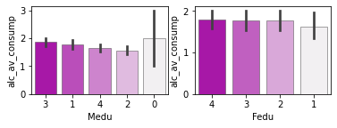

```python
pl.subplot (2, 2, 1)
sb.barplot(data=gm_alc,
           x='Medu',
           y='alc_av_consump',
           palette="light:m_r",
           edgecolor=".3",
           linewidth=.5)

pl.subplot (2, 2, 2)
sb.barplot(data=gf_alc,
           x='Fedu',
           y='alc_av_consump',
           palette="light:m_r",
           edgecolor=".3",
           linewidth=.5)
```

**Вывод:**

- **Опекун - мать:**
- Больше всего пьют те студенты, чей опекун не имеет образование.
- Меньше всего пьют те студенты, чей опекун закончил от 5 до 9 классов.
- **Опекун - отец:**
- Больше всего пьют те студенты, чей опекун имеет высшее образование.
- Меньше всего пьют те студенты, чей опекун закончил начальную школу.

**!** Однако у опекунов-отцов значения на графике отличаются крайне малой частью, из чего можно сделать вывод, что образование отца **ИМЕЕТ МЕНЬШЕЕ** влияние на употребление алкоголя студентом.

```
50 лучших учеников --> среднее потребление алкоголя:  1.0
50 худших учеников --> среднее потребление алкоголя:  1.0
```

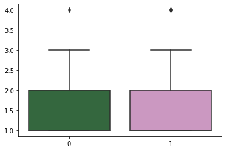

```python
# Сравните употребление алкоголя для 50 лучших учеников и 50 худших (по G3).
good_boys = data.nlargest(50, 'G3')['alc_av_consump']
bad_boys = data.nsmallest(50, 'G3')['alc_av_consump']

sb.boxplot(data=[good_boys, bad_boys], palette="cubehelix")

print('50 лучших учеников --> среднее потребление алкоголя: ', good_boys.median())
print('50 худших учеников --> среднее потребление алкоголя: ', bad_boys.median())
```

```
50 лучших учеников ОДИН КУРС --> среднее потребление алкоголя:  1.0
50 худших учеников ОДИН КУРС--> среднее потребление алкоголя:  2.0
```

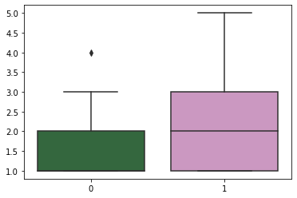

```python
# Сравните употребление алкоголя для 50 лучших учеников и 50 худших (по G3).
# ХОДЯТ НА ОДИН КУРС
both_alc = data.loc[data['both_course'] == 0]
good_boys = both_alc.nlargest(50, 'G3')['alc_av_consump']
bad_boys = both_alc.nsmallest(50, 'G3')['alc_av_consump']

sb.boxplot(data=[good_boys, bad_boys], palette="cubehelix")

print('50 лучших учеников ОДИН КУРС --> среднее потребление алкоголя: ', good_boys.median())
print('50 худших учеников ОДИН КУРС--> среднее потребление алкоголя: ', bad_boys.median())
```

```
50 лучших учеников ДВА КУРСА --> среднее потребление алкоголя:  1.0
50 худших учеников ДВА КУРС--> среднее потребление алкоголя:  1.0
```

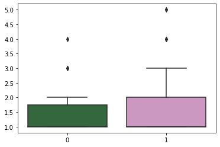

```python
# Сравните употребление алкоголя для 50 лучших учеников и 50 худших (по G3).
# ХОДЯТ НА ОБА КУРС
both_alc = data.loc[data['both_course'] == 1]
good_boys = both_alc.nlargest(50, 'G3')['alc_av_consump']
bad_boys = both_alc.nsmallest(50, 'G3')['alc_av_consump']

sb.boxplot(data=[good_boys, bad_boys], palette="cubehelix")

print('50 лучших учеников ДВА КУРСА --> среднее потребление алкоголя: ', good_boys.median())
print('50 худших учеников ДВА КУРС--> среднее потребление алкоголя: ', bad_boys.median())
```

**Вывод:**  
1) Отличники употребляют немного меньше алкоголя, чем студенты, которые учатся плохо.  
2) Больше всего пьют в среднем худшие ученики, кто посещает один курс. Они также пьют больше всех (4,5+).

```
Группа по португальскому:
50 лучших учеников --> среднее потребление алкоголя:  1.0
50 худших учеников --> Среднее потребление алкоголя:  2.0
```

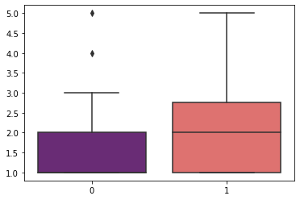

```python
# Выполните сравнение отдельно для каждого предмета (Math и Por). Дайте содержательный комментарий.
port = data[data['Subject']=='Por']
more_average = port.nlargest(50, 'G3')['alc_av_consump'].median()
less_average = port.nsmallest(50, 'G3')['alc_av_consump'].median()
print("Группа по португальскому:")
print("50 лучших учеников --> среднее потребление алкоголя: ", more_average, "\n50 худших учеников --> Среднее потребление алкоголя: ", less_average)
sb.boxplot(data=[port.nlargest(50, 'G3')['alc_av_consump'], port.nsmallest(50, 'G3')['alc_av_consump']], palette="magma" )
```

**Вывод:**  
Отличники употребляют меньше алкоголя.

```
Группа по математике:
50 лучших учеников --> среднее потребление алкоголя:  1.0
50 худших учеников --> Среднее потребление алкоголя:  1.0
```

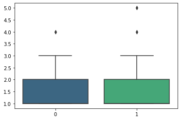

```python
math = data[data['Subject']=='Math']
more_average = math.nlargest(50, 'G3')['alc_av_consump'].median()
less_average = math.nsmallest(50, 'G3')['alc_av_consump'].median()
print("Группа по математике:")
print("50 лучших учеников --> среднее потребление алкоголя: ", more_average, "\n50 худших учеников --> Среднее потребление алкоголя: ", less_average)
sb.boxplot(data=[math.nlargest(50, 'G3')['alc_av_consump'], math.nsmallest(50, 'G3')['alc_av_consump']], palette="viridis" )
```

**Вывод:**  
Лучшие и худшие ученики из группы по матератике в среднем пьют одинаково.

**Общий вывод:**  
При сравнении 50 лучших и 50 худших учеников можно понять, что разница в употреблении алкоголя в среднем не особо велика, а где-то даже ее нет. Однако перевес в употреблении алкоголя идет в сторону "плохих" учеников.

### Задание 9

Оцените зависимость итоговой оценки от следующих признаков:

- Пола
- Времени в пути от дома до школы
- Наличия дополнительной помощи в учебе (от членов семьи или вообще)
- Посещения платных дополнительных занятий
- Наличия интернета
- Наличия романтических отношений
- Употребления алкоголя

```
Итоговая оценка
Парни: 11.0
Девушки: 12.0
```

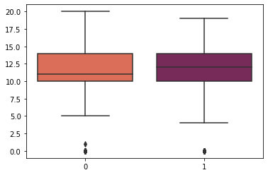

```python
# зависимость итоговой оценки от Пола
male_average = data.loc[data['sex']=='M', 'G3'].median()
female_average = data.loc[data['sex']=='F', 'G3'].median()
print(f"Итоговая оценка\nПарни: {male_average}\nДевушки: {female_average}")

sb.boxplot(data=[data.loc[data['sex']=='M', 'G3'], data.loc[data['sex']=='F', 'G3']], palette="rocket_r")
```

**Вывод:**  
1) **Наивысший** итоговый балл выше у **парней**, **низший** итоговый балл ниже у **девушек** .  
2) Средняя оценка выше у девушек.

```python
# зависимость итоговой оценки от Пола
male_average_both = data.loc[(data['sex']=='M') & (data['both_course']==1), 'G3'].median()
female_average_both = data.loc[(data['sex']=='F') & (data['both_course']==1), 'G3'].median()
print(f"Итоговая оценка ОБА курса\nПарни: {male_average_both}\nДевушки: {female_average_both}\n")

male_average_one = data.loc[(data['sex']=='M') & (data['both_course']==0), 'G3'].median()
female_average_one = data.loc[(data['sex']=='F') & (data['both_course']==0), 'G3'].median()
print(f"Итоговая оценка ОДИН курс\nПарни: {male_average_one}\nДевушки: {female_average_one}")
```

```
Итоговая оценка ОБА курса
Парни: 11.0
Девушки: 12.0

Итоговая оценка ОДИН курс
Парни: 11.0
Девушки: 11.0
```

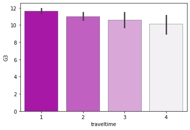

```python
# зависимость итоговой оценки от Времени в пути от дома до школы
sb.barplot(data=data,
           x='traveltime',
           y='G3',
           palette="light:m_r",
           edgecolor=".3",
           linewidth=.5)
```

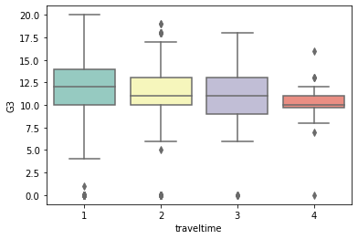

```python
sb.boxplot(x='traveltime',
           y='G3',
           data=data,
           palette="Set3")
```

**Вывод:**  
1) Студенты, живущие ближе всего к школе имеют лучшие средние баллы.  
2) Худшие стредние баллы у студентов, воторые живут дальше всего от школы.  
3) Наивысшие баллы у студентов, кто живет радом со школой.  
4) Самый низкий балл также у студентов, живущих рядом со школой.  
5) Студенты, которые добираются до школы от 15 до 30 мин и от 30 мин до 1 часа, имеют одинаковые средние баллы.

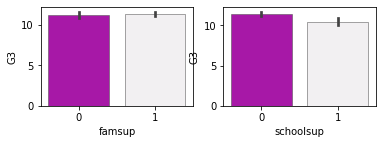

```python
# зависимость итоговой оценки от Наличия дополнительной помощи в учебе (от членов семьи или вообще)
pl.subplot (2, 2, 1)
sb.barplot(data=data,
           x='famsup',
           y='G3',
           palette="light:m_r",
           edgecolor=".3",
           linewidth=.5)
pl.subplot (2, 2, 2)
sb.barplot(data=data,
           x='schoolsup',
           y='G3',
           palette="light:m_r",
           edgecolor=".3",
           linewidth=.5)
```

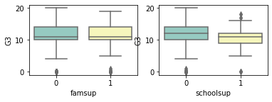

```python
pl.subplot (2, 2, 1)
sb.boxplot(x='famsup',
           y='G3',
           data=data,
           palette="Set3")

pl.subplot (2, 2, 2)
sb.boxplot(x='schoolsup',
           y='G3',
           data=data,
           palette="Set3")
```

**Вывод:**  
1) На среднюю итоговую оценку не влияет **помощь семьи** с учебой.  
2) Седняя итоговая оценка у тех, у кого **нет помощи по учебе(schoolsup)** выше.  
3) Наивысший балл получили те, кому не помогали с учебой (как и низший).

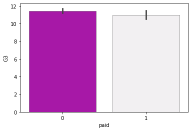

```python
# зависимость итоговой оценки от Посещения платных дополнительных занятий
sb.barplot(data=data,
           x='paid',
           y='G3',
           palette="light:m_r",
           edgecolor=".3",
           linewidth=.5)
```

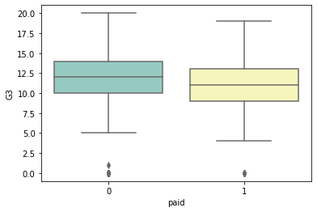

```python
sb.boxplot(x='paid',
           y='G3',
           data=data,
           palette="Set3")
```

**Вывод:**  
1) Интересно отметить, что студенты, не посещающие дополнительные платные занятия, получают оценки выше.

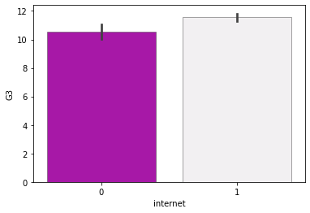

```python
# зависимость итоговой оценки от Наличия интернета
sb.barplot(data=data,
           x='internet',
           y='G3',
           palette="light:m_r",
           edgecolor=".3",
           linewidth=.5)
```

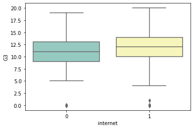

```python
sb.boxplot(x='internet',
           y='G3',
           data=data,
           palette="Set3")
```

**Вывод:**  
1) Студенты, которые имеют доступ в Интернет, получают более высокие оценки.

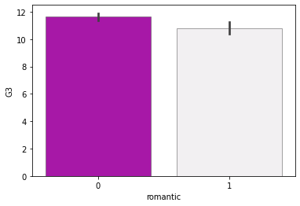

```python
# зависимость итоговой оценки от Наличия романтических отношений
sb.barplot(data=data,
           x='romantic',
           y='G3',
           palette="light:m_r",
           edgecolor=".3",
           linewidth=.5)
```

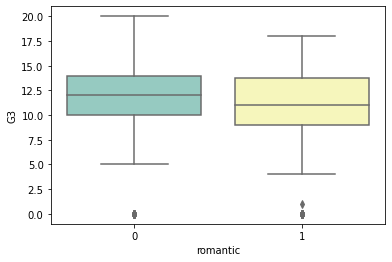

```python
sb.boxplot(x='romantic',
           y='G3',
           data=data,
           palette="Set3")
```

**Вывод:**  
1) Студенты, которые находятся в романтических отношениях, учатся хуже и получают более плохие оценки.

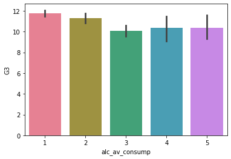

```python
# зависимость итоговой оценки от Употребления алкоголя
sb.barplot(data=data, x='alc_av_consump', y='G3', palette="husl")
```

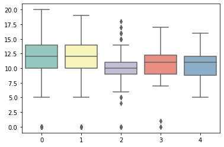

```python
sb.boxplot(data=[data.loc[data['alc_av_consump']==1, 'G3'],
                 data.loc[data['alc_av_consump']==2, 'G3'],
                 data.loc[data['alc_av_consump']==3, 'G3'],
                 data.loc[data['alc_av_consump']==4, 'G3'],
                 data.loc[data['alc_av_consump']==5, 'G3']],
           palette="Set3")
```

**Вывод:**  
1) Лучше всего учатся те студенты, кто меньше всего пьет.  
2) Худшие оценки имеют те, кто пьет "средне" и "много".  
3) Лучшие показатели по средним оценкам также у студентов, кто мало пьет алкоголя.

### Задание 10

Добавьте в данные новый признак - итоговая оценка по 4-х балльной шкале:

- Отлично: 18 <= `G3` <= 20
- Хорошо: 14 <= `G3` <= 17
- Удовлетворительно: 8 <= `G3` <= 13
- Неудовлетворительно: `G3` < 8

Оцените распределение нового признака в зависимости от признака `reason` (причина выбора школы). Дайте содержательный комментарий.

```python
def make_4grade(g3):
    if 18 <= g3 <= 20:
        return 5
    elif 14 <= g3 <= 17:
        return 4
    elif 8 <= g3 <= 13:
        return 3
    elif g3 < 8:
        return 2
```

```python
data['grade4'] = data.loc[:, 'G3'].apply(make_4grade)
```

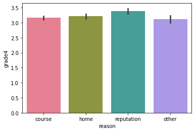

```python
sb.barplot(data=data, x='reason', y='grade4', palette="husl")
```

**Вывод:**  
1) Оценка **лучше** у тех студентов, кто выбирал школу за ее **репутацию** .  
2) Средние оценки студентов, которые выбрали школу за **курсы** и **другое** одинаковые.

### Задание 11 наверху!

### Задание 12

Предложите простую модель для определения (предсказания) итоговой оценки студента по 4-х балльной системе. Оцените точность предложенной модели.

```python
not_modif_data = pd.read_csv("students_data.csv")
```

```python
not_modif_data['grade4'] = data.loc[:, 'G3'].apply(make_4grade)
not_modif_data.head()
```

|  | ID | Subject | school | sex | age | address | famsize | Pstatus | Medu | Fedu | Mjob | Fjob | reason | guardian | traveltime | studytime | failures | schoolsup | famsup | paid | activities | nursery | higher | internet | romantic | famrel | freetime | goout | Dalc | … |
| --- | --- | --- | --- | --- | --- | --- | --- | --- | --- | --- | --- | --- | --- | --- | --- | --- | --- | --- | --- | --- | --- | --- | --- | --- | --- | --- | --- | --- | --- | --- |
| 0 | 100097 | Por | GP | F | 16 | U | GT3 | A | 3 | 4 | services | other | course | father | 1 | 1 | 0 | no | no | no | no | yes | yes | yes | no | 3.0 | 2 | 1 | 1.0 | … |
| 1 | 101021 | Por | GP | F | 17 | U | GT3 | T | 3 | 2 | other | other | course | mother | 1 | 2 | 0 | no | no | no | yes | no | yes | yes | no | 5.0 | 3 | 4 | 1.0 | … |
| 2 | 102965 | Por | GP | M | 16 | U | LE3 | T | 1 | 2 | health | services | course | mother | 2 | 1 | 2 | no | no | no | no | no | yes | yes | no | 4.0 | 4 | 5 | 3.0 | … |
| 3 | 102989 | Por | MS | M | 17 | U | GT3 | T | 2 | 3 | other | services | home | father | 2 | 2 | 0 | no | no | no | yes | yes | yes | yes | no | 4.0 | 4 | 3 | 1.0 | … |
| 4 | 103131 | Por | GP | F | 16 | U | GT3 | T | 1 | 1 | at_home | other | home | mother | 2 | 1 | 0 | no | yes | no | no | yes | yes | no | NaN | 4.0 | 3 | 2 | 1.0 | … |

- Во-первых, нужно посмотреть какие переменные **связаны с итоговой оценкой** (4х балльная систем). Для этого нужно найти **коэффициент корреляции**, для определения наиболее полезных переменных для прогнозирования оценки. (Данное значение изменяется от -1 до +1 и измеряет направление и силу линейной связи между двумя переменными)
- Далее есть смысл рассматривать признаки, которые имеют **наибольшую корреляцию(отрицательную или положительную)** с итоговой оценкой.

```python
not_modif_data.corr()['grade4'].sort_values()
```

```
failures     -0.308620
Dalc         -0.147734
Walc         -0.128976
health       -0.108104
traveltime   -0.095412
goout        -0.093532
age          -0.082829
absences     -0.070514
freetime     -0.039766
ID            0.011970
famrel        0.059039
studytime     0.171330
G1            0.775604
G2            0.839436
G3            0.874279
grade4        1.000000
Name: grade4, dtype: float64
```

- Из представленных данных можнно увидеть, что **"failures", "Dalc", "Walc"** **отрицательно** коррелируют с оценкой. Эта отрицательная корреляция указывает на то, что по мере увеличения этих переменных итоговая оценка имеет тенденцию к снижению.
- А **"famrel", "studytime"** - **положительно** коррелируют с оценкой.

```python
# ! Корреляции могут быть рассчитаны только между числовыми переменными !
category = not_modif_data.select_dtypes('object')
encod_data = pd.get_dummies(category) # One hot encoding
encod_data['grade4'] = not_modif_data['grade4']
encod_data.corr()['grade4'].sort_values()
```

```
higher_no           -0.201535
Medu_1              -0.130583
schoolsup_yes       -0.129193
Fedu_1              -0.119377
Subject_Math        -0.116409
                       ...
schoolsup_no         0.129193
reason_reputation    0.132514
higher_yes           0.201535
Medu_4               0.205027
grade4               1.000000
Name: grade4, Length: 65, dtype: float64
```

- "higher_no", "Medu_1", "schoolsup_yes", "Fedu_1", "Subject_Math" - **отрицательно** коррелируют с оценкой;
- "schoolsup_no", reason_reputation, higher_yes, Medu_4 - **положительно** коррелируют с оценкой;

Для дальнейшего анализа, я думаю, наиболее подойдут следующе признаки:

- **failures:** число завалов студента по предыдущим курсам
- **higher:** cобирается получать высшее образование
- **Medu:** уровень образования матери
- **studytime:** кол-во часов на учебу в неделю
- **schoolsup:** доп. помощь в учебе
- **Dalc:** потребление алкоголя в будни

```python
high_corr_data = data.copy()
high_corr_data = high_corr_data.drop(['school', 'address', 'famsize',
                                      'Pstatus', 'reason','guardian', 'famsup',
                                      'paid', 'activities', 'nursery', 'internet',
                                      'romantic', 'famrel', 'freetime'],
                                     axis=1)
high_corr_data
```

|  | ID | Subject | sex | age | Medu | Fedu | Mjob | Fjob | traveltime | studytime | failures | schoolsup | higher | goout | Dalc | Walc | health | absences | G1 | G2 | G3 | both_course | alc_av_consump | grade4 |
| --- | --- | --- | --- | --- | --- | --- | --- | --- | --- | --- | --- | --- | --- | --- | --- | --- | --- | --- | --- | --- | --- | --- | --- | --- |
| 0 | 100097 | Por | F | 16 | 3 | 4 | services | other | 1 | 1 | 0 | 0 | 1 | 1 | 1 | 4 | 5 | 12 | 15 | 13 | 14 | 0 | 2 | 4 |
| 1 | 101021 | Por | F | 17 | 3 | 2 | other | other | 1 | 2 | 0 | 0 | 1 | 4 | 1 | 3 | 3 | 2 | 17 | 18 | 17 | 0 | 2 | 4 |
| 2 | 102965 | Por | M | 16 | 1 | 2 | health | services | 2 | 1 | 2 | 0 | 1 | 5 | 3 | 5 | 5 | 0 | 9 | 8 | 10 | 0 | 4 | 3 |
| 3 | 102989 | Por | M | 17 | 2 | 3 | other | services | 2 | 2 | 0 | 0 | 1 | 3 | 1 | 1 | 3 | 4 | 14 | 15 | 16 | 0 | 1 | 4 |
| 4 | 103131 | Por | F | 16 | 1 | 1 | at_home | other | 2 | 1 | 0 | 0 | 1 | 2 | 1 | 4 | 5 | 2 | 12 | 13 | 13 | 0 | 2 | 3 |
| ... | ... | ... | ... | ... | ... | ... | ... | ... | ... | ... | ... | ... | ... | ... | ... | ... | ... | ... | ... | ... | ... | ... | ... | ... |
| 1039 | 997832 | Math | F | 15 | 3 | 3 | services | services | 2 | 3 | 2 | 0 | 1 | 1 | 2 | 3 | 3 | 8 | 10 | 10 | 10 | 1 | 2 | 3 |
| 1040 | 997897 | Por | M | 15 | 2 | 1 | health | services | 1 | 2 | 0 | 0 | 1 | 2 | 1 | 1 | 5 | 4 | 10 | 9 | 10 | 1 | 1 | 3 |
| 1041 | 998425 | Por | F | 16 | 1 | 1 | at_home | other | 3 | 2 | 0 | 0 | 1 | 2 | 1 | 1 | 1 | 0 | 16 | 17 | 18 | 0 | 1 | 5 |
| 1042 | 999143 | Por | M | 16 | 2 | 1 | at_home | other | 4 | 1 | 0 | 0 | 1 | 1 | 1 | 1 | 2 | 4 | 9 | 9 | 11 | 0 | 1 | 3 |
| 1043 | 999194 | Por | M | 17 | 1 | 3 | other | other | 3 | 2 | 1 | 0 | 1 | 4 | 1 | 4 | 5 | 14 | 12 | 11 | 11 | 1 | 2 | 3 |

1044 rows × 24 columns

- Далее я **исключаю** столбцы, которые **не особо влияют** на итоговую оценку.

```python
high_corr_data['pass_fail'] = high_corr_data['grade4'].apply(lambda x: 'Fail' if x < 3 else 'Pass')
high_corr_data['pass_fail'].value_counts()
```

```
Pass    944
Fail    100
Name: pass_fail, dtype: int64
```

- Далее я показываю на графиках как признаки, сильно влияющие на итоговую оценку, можно разбить на две группы - **сдал/не сдал** и в дальнейшем отталкиваясь от этих знаний можно обучать модель предсказывать оценки.

```python
# failures: число завалов студента по предыдущим курсам

fp_failures = high_corr_data.groupby(['failures'])['pass_fail'].value_counts().unstack()
fp_failures
```

| pass_fail failures | Fail | Pass |
| --- | --- | --- |
| 0 | 50 | 811 |
| 1 | 26 | 94 |
| 2 | 12 | 21 |
| 3 | 12 | 18 |

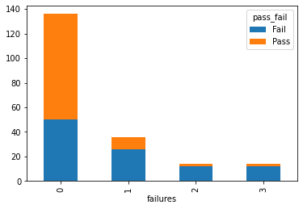

```python
fp_fl = pd.crosstab(high_corr_data.failures, high_corr_data.pass_fail).apply(lambda x: x/x.sum() * 100)
fp_fl.plot(kind = 'bar', stacked = True)
```

- Очевидно, что чем меньше "завалов", тем с большей вероятностью студент сдаст предмент.
- Шансы не сдать с каждым разом увеличиваются у тех, кто хоть раз заваливал курс.

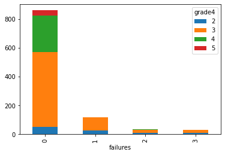

```python
fp_f = high_corr_data.groupby(['failures'])['grade4'].value_counts().unstack()
fp_f.plot(kind = 'bar', stacked = True)
```

- Смотря на те же данные, но с разбивной на оценки и провалы, можно предсказать, что чем меньше будет у человека провалов,тем выше будет его оценки.

```python
# higher: cобирается получать высшее образование

fp_higher = high_corr_data.groupby(['higher'])['pass_fail'].value_counts().unstack()
fp_higher
```

| pass_fail higher | Fail | Pass |
| --- | --- | --- |
| 0 | 20 | 69 |
| 1 | 80 | 875 |